# MS brain age UCL MAGNIMS analysis

James Cole - December 2019. Built with R version 3.5.2  
This is Notebook contains the final brain age analysis of MS patient data and controls from the UCL cohort, the MAGNIMS consortium and the Imperial College London PET study (n=25). The analysis uses brain-predicted age difference (brain-PAD) to look at brain ageing in the context of MS. The brain-PAD values were generated in PRONTO, using an independent healthy (n=2001) training dataset, and the values were corrected for proportional bias using the intercept and slope of the age by brain-predicted age regression in the training dataset.

# Set-up

## Clear workspace, set colour palette

```r
rm(list = ls()) ## clear workspace
ms.palette <- c("darkgreen", "darkorange", "red", "blue", "purple") # define MS colour scheme for groups
```

## Get data from CSV and define longitudinal data.frames

```r
df <- read.csv("MS_brain_age_final_long.csv")
df$subtype <- factor(df$subtype, levels = c("control", "CIS", "RRMS", "SPMS", "PPMS")) # reorder subtype factor to put controls first
df$Cohort <- recode(df$Cohort, JR1 = "Imperial", C0 = "UCL0", C1 = "UCL1", C2 = "UCL2", C3 = "UCL3", C4 = "UCL4" ,C5 = "UCL5", C6 = "UCL6", C7 = "UCL7", A = "Amsterdam", B = "Barcelona", G = "Graz", M = "Milan", R = "Rome", S = "Siena")
df$wb_vol_ratio_icv <- df$WBV / df$ICV
```

## Get data on Brain Age Healthy Training dataset

```r
banc <- read.csv("/Users/jcole/Work/Brain ageing/BANC_2015/BANC_N2003_age_sex_Brain_age_predictions.csv")
```

## Exclude participants with errors in the database & correct time since diagnosis errors

```r
tmp <- df[df$Cohort == 'Amsterdam',] %>% group_by(PatientID) %>% dplyr::summarize(sd = sd(age_at_scan)) %>% arrange(desc(sd)) %>% filter(sd > 2)
excluded_IDs <- sort(tmp$PatientID)
# excluded_IDs <- unique(df[which(df$age_at_scan < df$age_at_baseline_scan1),1])
excluded_scans <- (df %>% filter(str_detect(PatientID, paste(excluded_IDs, collapse = "|"))))["ScanName"]
df <- df %>%
  filter(!str_detect(PatientID, paste(excluded_IDs, collapse = "|")))
rm(tmp)
```

There were 13 subjects with 38 scans excluded in total. Data entry errors in original spreadsheet; age at baseline not consistent within subject.

## Load data for lesion filling analysis

```r
## read in data
lesion_df <- read.csv(file = '~/Work/Brain ageing/Collaborations/MS/MAGNIMS/MAGNIMS20171224_final.csv')
lesion_df$subtype <- factor(lesion_df$subtype, levels = c("control", "CIS", "RRMS", "SPMS", "PPMS"))
## create ICV ratio variables
lesion_df <- lesion_df %>%
  mutate(ICV = GMV + WMV + CSFV) %>%
  mutate(gm_icv_ratio = GMV/ICV) %>%
  mutate(wm_icv_ratio = WMV/ICV)
```

## Recode scanner status variable to field strength

Pre-post 2004 data only available for one site.

```r
table(df$scanner_status)
```

```
          1.5T 1.5T_post_2004  1.5T_pre_2004             3T
          2257             19            447            842
```

```r
df$field_strength <- recode(df$scanner_status, `1.5T_pre_2004` = "1.5T", `1.5T_post_2004` = "1.5T")
table(df$field_strength)
```

```
1.5T   3T
2723  842
```

## Generate baseline only data.frame and show data frame structure

```r
df.bl <- df[(df$age_at_baseline_scan1 == df$age_at_scan),] # define baseline data.frame
str(df)
```

```
'data.frame':   3565 obs. of  34 variables:
 $ PatientID                         : Factor w/ 1367 levels "AMSTERDAM_4001",..: 1 1 1 2 2 2 3 3 3 4 ...
 $ Cohort                            : Factor w/ 15 levels "Amsterdam","Barcelona",..: 1 1 1 1 1 1 1 1 1 1 ...
 $ scanner_status                    : Factor w/ 4 levels "1.5T","1.5T_post_2004",..: 1 1 1 1 1 1 1 1 1 1 ...
 $ gender                            : Factor w/ 2 levels "female","male": 2 2 2 1 1 1 1 1 1 1 ...
 $ control0ppms1cisoforever2other3   : int  3 3 3 3 3 3 3 3 3 3 ...
 $ control0rest1                     : Factor w/ 2 levels "control","MS": 2 2 2 2 2 2 2 2 2 2 ...
 $ control0ms1cis2                   : Factor w/ 3 levels "CIS","control",..: 3 3 3 3 3 3 3 3 3 3 ...
 $ age_at_baseline_scan1             : num  57.8 57.8 57.8 44.4 44.4 ...
 $ disease_duration_at_baseline_scan1: num  6.8 6.8 6.8 6.38 6.38 ...
 $ DMT_YesNoNA                       : Factor w/ 2 levels "NO","YES": 1 1 1 1 1 1 2 2 2 2 ...
 $ DMTYes1                           : Factor w/ 2 levels "No treatment",..: 1 1 1 1 1 1 2 2 2 2 ...
 $ EDSSbaseline                      : num  2.5 2.5 2.5 3 3 3 4 4 4 2.5 ...
 $ NoScans                           : int  3 3 3 3 3 3 3 3 3 2 ...
 $ FUTimeMax                         : num  2.32 2.32 2.32 2.35 2.35 ...
```

[output cut: 20 more lines]

# Basic stats

## Total number of subjects, and by group

The total number of subjects included was n = 1354

The total number of MS patients (including CIS) was n = 1204 and healthy controls was n = 150

## Number of scans in total and per group

Total number of scans = 3565

## Number of people with 2 or more scans

```r
df.bl %>%
  filter(NoScans >= 2) %>%
  group_by(control0rest1) %>%
  tally()
```

| control0rest1 | n |
| --- | --- |
| control | 111 |
| MS | 1155 |

## Number of people with 3 or more scans

```r
df.bl %>%
  filter(NoScans >= 3) %>%
  group_by(control0rest1) %>%
  tally()
```

| control0rest1 | n |
| --- | --- |
| control | 64 |
| MS | 509 |

## Generate demographics table using qwarps2

```r
options(qwraps2_markup = "markdown", digits = 2)
table1 <-
  list("N" =
         list("Control" = ~ qwraps2::n_perc0(control0rest1 == "control", na_rm = T),
              "MS"  = ~ qwraps2::n_perc0(control0rest1 == "MS", na_rm = T)),
       "N with follow-up" =
         list("Yes" = ~ sum(NoScans>1)),
     "Gender" =
       list("Female" = ~ qwraps2::n_perc0(gender == "female", show_symbol = T),
            "Male"  = ~ qwraps2::n_perc0(gender == "male", show_symbol = T)),
        "Number of scans" =
       list("min" = ~ min(NoScans),
            "max" = ~ max(NoScans),
            "mean (sd)" = ~ qwraps2::mean_sd(NoScans)),
       "Age at baseline scan (years)" =
       list("min" = ~ min(age_at_baseline_scan1),
            "max" = ~ max(age_at_baseline_scan1),
            "mean (sd)" = ~ qwraps2::mean_sd(age_at_baseline_scan1)),
       "Brain-predicted age at baseline scan (years)" =
       list("min" = ~ min(BrainAge),
            "max" = ~ max(BrainAge),
            "mean (sd)" = ~ qwraps2::mean_sd(BrainAge)),
       "Disease duration at baseline (years)" =
       list("min" = ~ min(disease_duration, na.rm = T),
            "max" = ~ max(disease_duration, na.rm = T),
            "mean (sd)" = ~ qwraps2::mean_sd(disease_duration, na_rm = T, show_n = "never")),
        "EDSS at baseline " =
       list("min" = ~ min(EDSSbaseline, na.rm = T),
            "max" = ~ max(EDSSbaseline, na.rm = T),
            "mean (sd)" = ~ qwraps2::mean_sd(EDSSbaseline, na_rm = T, show_n = "never")),
       "MS subtype" =
       list("CIS" = ~ qwraps2::n_perc0(subtype == "CIS", show_symbol = T),
            "RRMS"  = ~ qwraps2::n_perc0(subtype == "RRMS", show_symbol = T),
            "SPMS"  = ~ qwraps2::n_perc0(subtype == "SPMS", show_symbol = T),
            "PPMS"  = ~ qwraps2::n_perc0(subtype == "PPMS", show_symbol = T)),
       "Treatment" =
         list("Yes" = ~ qwraps2::n_perc0(DMT_YesNoNA == "YES", na_rm = T, show_symbol = T),
              "No"  = ~ qwraps2::n_perc0(DMT_YesNoNA == "NO", na_rm = T, show_symbol = T),
              "Missing" = ~ sum(is.na(DMT_YesNoNA)))
       )
print(summary_table(dplyr::group_by(df.bl, control0rest1), table1),
      rtitle = "Sample Chararcteristics",
      cnames = c("Controls", "MS patients"))
```

| Sample Chararcteristics | Controls | MS patients |
| --- | --- | --- |
| **N** |  |  |
| Control | 150 (100) | 0 (0) |
| MS | 0 (0) | 1,204 (100) |
| **N with follow-up** |  |  |
| Yes | 111 | 1155 |
| **Gender** |  |  |
| Female | 82 (55%) | 771 (64%) |
| Male | 68 (45%) | 433 (36%) |
| **Number of scans** |  |  |
| min | 1 | 1 |
| max | 10 | 7 |
| mean (sd) | 2.82 ± 1.90 | 2.61 ± 1.01 |
| **Age at baseline scan (years)** |  |  |
| min | 23 | 15 |
| max | 66 | 68 |
| mean (sd) | 37.29 ± 9.96 | 39.41 ± 10.76 |
| **Brain-predicted age at baseline scan (years)** |  |  |
| min | 14.5 | 7.4 |
| max | 70 | 92 |
| mean (sd) | 38.43 ± 11.12 | 50.27 ± 14.90 |
| **Disease duration at baseline (years)** |  |  |
| min | Inf | 0 |
| max | -Inf | 48 |
| mean (sd) | NaN ± NA | 7.26 ± 7.96 |
| **EDSS at baseline** |  |  |
| min | Inf | 0 |
| max | -Inf | 9 |
| mean (sd) | NaN ± NA | 2.60 ± 1.95 |
| **MS subtype** |  |  |
| CIS | 0 (0%) | 296 (25%) |
| RRMS | 0 (0%) | 677 (56%) |
| SPMS | 0 (0%) | 111 (9%) |
| PPMS | 0 (0%) | 120 (10%) |
| **Treatment** |  |  |
| Yes | 0 (NaN%) | 475 (41%) |
| No | 0 (NaN%) | 675 (59%) |
| Missing | 150 | 54 |

## Length of follow-up

Get length of follow-up from longitudinal database.

```r
options(digits = 3) ## return digits option to default
df %>%
  filter(NoScans >= 2) %>%
  group_by(PatientID) %>%
  slice(which.max(interval)) %>%
  # top_n(n = 1, wt = interval) %>%
  group_by(control0rest1) %>%
  dplyr::summarise(mean(interval), sd(interval), min(interval), max(interval))
```

| control0rest1 | mean(interval) | sd(interval) | min(interval) | max(interval) |
| --- | --- | --- | --- | --- |
| control | 2.0 | 1.4 | 0.50 | 6 |
| MS | 3.4 | 3.1 | 0.23 | 15 |

```r
options(digits = 7) ## return digits option to default
```

## Demographics by MS subtype

```r
options(qwraps2_markup = "markdown", digits = 2)
table1 <-
  list("N with follow-up" =
         list("Yes" = ~ sum(NoScans>1)),
    "Gender" =
       list("Female" = ~ qwraps2::n_perc0(gender == "female", show_symbol = T),
            "Male"  = ~ qwraps2::n_perc0(gender == "male", show_symbol = T)),
        "Number of scans" =
       list("min" = ~ min(NoScans),
            "max" = ~ max(NoScans),
            "mean (sd)" = ~ qwraps2::mean_sd(NoScans)),
       "Age at baseline scan (years)" =
       list("min" = ~ min(age_at_baseline_scan1),
            "max" = ~ max(age_at_baseline_scan1),
            "mean (sd)" = ~ qwraps2::mean_sd(age_at_baseline_scan1)),
       "Brain-predicted age at baseline scan (years)" =
       list("min" = ~ min(BrainAge),
            "max" = ~ max(BrainAge),
            "mean (sd)" = ~ qwraps2::mean_sd(BrainAge)),
       "Disease duration at baseline (years)" =
       list("min" = ~ min(disease_duration, na.rm = T),
            "max" = ~ max(disease_duration, na.rm = T),
            "mean (sd)" = ~ qwraps2::mean_sd(disease_duration, na_rm = T, show_n = "never")),
        "EDSS at baseline " =
       list("min" = ~ min(EDSSbaseline, na.rm = T),
            "max" = ~ max(EDSSbaseline, na.rm = T),
            "mean (sd)" = ~ qwraps2::mean_sd(EDSSbaseline, na_rm = T, show_n = "never")),
       "Treatment" =
         list("Yes" = ~ qwraps2::n_perc0(DMT_YesNoNA == "YES", na_rm = T, show_symbol = T),
              "No"  = ~ qwraps2::n_perc0(DMT_YesNoNA == "NO", na_rm = T, show_symbol = T),
              "Missing" = ~ sum(is.na(DMT_YesNoNA)))
       )
print(summary_table(dplyr::group_by(df.bl, subtype), table1),
      rtitle = "Sample Chararcteristics",
      cnames = c("Controls", "CIS", "RRMS", "SPMS", "PPMS"))
```

| Sample Chararcteristics | Controls | CIS | RRMS | SPMS | PPMS |
| --- | --- | --- | --- | --- | --- |
| **N with follow-up** |  |  |  |  |  |
| Yes | 111 | 279 | 653 | 104 | 119 |
| **Gender** |  |  |  |  |  |
| Female | 82 (55%) | 199 (67%) | 453 (67%) | 67 (60%) | 52 (43%) |
| Male | 68 (45%) | 97 (33%) | 224 (33%) | 44 (40%) | 68 (57%) |
| **Number of scans** |  |  |  |  |  |
| min | 1 | 1 | 1 | 1 | 1 |
| max | 10 | 5 | 7 | 3 | 5 |
| mean (sd) | 2.82 ± 1.90 | 2.44 ± 0.98 | 2.71 ± 1.05 | 2.25 ± 0.56 | 2.80 ± 1.07 |
| **Age at baseline scan (years)** |  |  |  |  |  |
| min | 23 | 15 | 18 | 30 | 19 |
| max | 66 | 55 | 66 | 68 | 65 |
| mean (sd) | 37.29 ± 9.96 | 33.01 ± 8.08 | 38.83 ± 9.68 | 50.11 ± 9.39 | 48.55 ± 10.04 |
| **Brain-predicted age at baseline scan (years)** |  |  |  |  |  |
| min | 14.5 | 13.7 | 7.4 | 40.2 | 31.0 |
| max | 70 | 82 | 92 | 89 | 84 |
| mean (sd) | 38.43 ± 11.12 | 37.60 ± 10.01 | 51.33 ± 13.32 | 67.36 ± 10.42 | 59.77 ± 10.90 |
| **Disease duration at baseline (years)** |  |  |  |  |  |
| min | Inf | 0.0 | 0.0 | 2.5 | 1.0 |
| max | -Inf | 18 | 42 | 48 | 27 |
| mean (sd) | NaN ± NA | 0.52 ± 1.50 | 7.67 ± 7.31 | 17.44 ± 9.04 | 6.65 ± 5.63 |
| **EDSS at baseline** |  |  |  |  |  |
| min | Inf | 0 | 0 | 3 | 2 |
| max | -Inf | 4.5 | 6.5 | 9.0 | 8.0 |
| mean (sd) | NaN ± NA | 1.36 ± 1.02 | 2.12 ± 1.40 | 5.83 ± 1.20 | 5.10 ± 1.32 |
| **Treatment** |  |  |  |  |  |
| Yes | 0 (NaN%) | 60 (20%) | 356 (56%) | 51 (50%) | 8 (7%) |
| No | 0 (NaN%) | 234 (80%) | 285 (44%) | 52 (50%) | 104 (93%) |
| Missing | 150 | 2 | 36 | 8 | 8 |

## Length of follow-up

Get length of follow-up from longitudinal database.

```r
options(digits = 3) ## return digits option to default
df %>%
  filter(NoScans >= 2) %>%
  group_by(PatientID) %>%
  slice(which.max(interval)) %>%
  # top_n(n = 1, wt = interval) %>%
  group_by(subtype) %>%
  dplyr::summarise(mean(interval), sd(interval), min(interval), max(interval))
```

| subtype | mean(interval) | sd(interval) | min(interval) | max(interval) |
| --- | --- | --- | --- | --- |
| control | 2.0 | 1.4 | 0.50 | 6.0 |
| CIS | 3.6 | 4.0 | 0.23 | 15.0 |
| RRMS | 3.6 | 3.1 | 0.45 | 15.0 |
| SPMS | 2.4 | 1.1 | 0.51 | 5.5 |
| PPMS | 2.9 | 1.6 | 0.83 | 6.0 |

```r
options(digits = 7) ## return digits option to default
```

## Correlations between demographics and clinical variables

Use corrplot package.

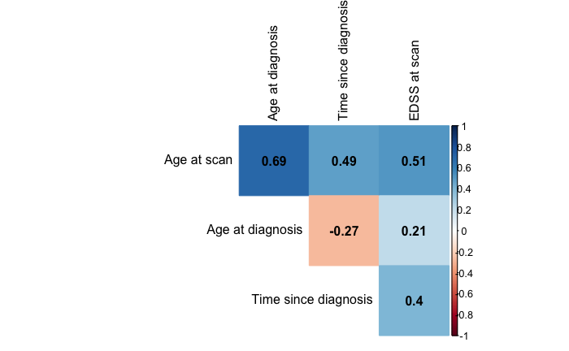

```r
cor.mat <- cbind(df.bl$age_at_scan, df.bl$disease_onset_age, df.bl$disease_duration, df.bl$EDSSatScan)
colnames(cor.mat) <- c("Age at scan", "Age at diagnosis", "Time since diagnosis", "EDSS at scan")
corrplot(cor(cor.mat, use = "pairwise"), type = "upper", method = "color", addCoef.col = T, tl.col = "black", diag = F)
```

## Age histograms

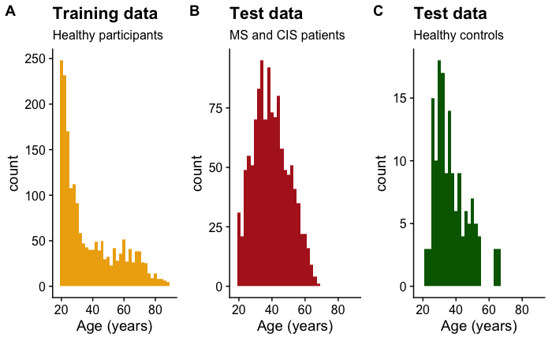

```r
p <- ggplot() + xlab("Age (years)") + xlim(c(18,90)) + theme_cowplot()
banc_plot <- p + geom_histogram(aes(x = age), fill = "darkgoldenrod2", binwidth = 2, data = banc, main = "Test") + labs(title = "Training data", subtitle = "Healthy participants")
ms_plot <- p + geom_histogram(aes(x = age_at_scan), fill = "firebrick",  binwidth = 2, data = subset(df.bl, df.bl$control0rest1 == "MS"))  + labs(title = "Test data", subtitle = "MS and CIS patients")
hc_plot <- p + geom_histogram(aes(x = age_at_scan), fill = "darkgreen", binwidth = 2, data = subset(df.bl, df.bl$control0rest1 == "control"))  + labs(title = "Test data", subtitle = "Healthy controls")
p2 <- cowplot::plot_grid(banc_plot, ms_plot, hc_plot, labels = "AUTO", nrow = 1)
p2
cowplot::save_plot("~/Work/Articles/Brain age/MS/figures/BANC_MAGNIMS_age_histograms.pdf", p2, base_asp = 2.5)
```

# Baseline brain-age analysis

```r
describeBy(df.bl$BrainPAD, df.bl$control0rest1, mat = T, digits = 3) # brain-PAD by MS patient vs. controls
```

```
    item  group1 vars    n mean   sd median trimmed mad min max range  skew kurtosis   se
X11    1 control    1  150  1.1  6.7   0.64     1.2 6.5 -17  22    39 0.032    0.072 0.55
X12    2      MS    1 1204 10.9 10.2   9.44    10.2 9.7 -18  49    67 0.600    0.315 0.29
```

## Evalute potential covariates

```r
table(df.bl$Cohort, df.bl$field_strength)
```

```
            1.5T  3T
  Amsterdam  193   0
  Barcelona   62  90
  UCL0         0  21
  UCL1       148   6
  UCL2         0  16
  UCL3         0 147
  UCL4         0  35
  UCL5        50   0
  UCL6        59   0
  UCL7        34   0
  Graz       174   0
  Imperial     0  25
  Milan       60  54
  Rome        71   0
  Siena      109   0
```

```r
fit <- lm(BrainPAD ~ poly(age_at_baseline_scan1, 2) + gender + ICV + field_strength + Cohort, data = df.bl)
anova(fit)
```

```
Analysis of Variance Table

Response: BrainPAD
                                 Df Sum Sq Mean Sq F value Pr(>F)
poly(age_at_baseline_scan1, 2)    2    445     223    2.36 0.0948 .
gender                            1    741     741    7.86 0.0051 **
ICV                               1     12      12    0.13 0.7223
field_strength                    1    693     693    7.34 0.0068 **
Cohort                           14  17705    1265   13.40 <2e-16 ***
Residuals                      1334 125886      94
---
Signif. codes:  0 ‘***’ 0.001 ‘**’ 0.01 ‘*’ 0.05 ‘.’ 0.1 ‘ ’ 1
```

## Hierarchical partitioning of brain-PAD

```r
a <- lm(BrainPAD ~ poly(age_at_baseline_scan1, 2) + gender + wb_vol_ratio_icv +  field_strength + Cohort, data = df.bl)
summary(a)
```

```
Call:
lm(formula = BrainPAD ~ poly(age_at_baseline_scan1, 2) + gender +
    wb_vol_ratio_icv + field_strength + Cohort, data = df.bl)

Residuals:
   Min     1Q Median     3Q    Max
-33.64  -4.49  -0.23   4.18  32.06

Coefficients:
                                Estimate Std. Error t value Pr(>|t|)
(Intercept)                      142.658      3.724   38.31  < 2e-16 ***
poly(age_at_baseline_scan1, 2)1 -164.500      8.746  -18.81  < 2e-16 ***
poly(age_at_baseline_scan1, 2)2  -11.913      7.075   -1.68  0.09247 .
gendermale                        -1.159      0.403   -2.87  0.00414 **
wb_vol_ratio_icv                -164.464      4.565  -36.03  < 2e-16 ***
field_strength3T                  -1.744      0.826   -2.11  0.03491 *
CohortBarcelona                   -3.691      0.917   -4.03  6.0e-05 ***
CohortUCL0                         0.774      1.803    0.43  0.66778
CohortUCL1                        -2.111      0.784   -2.69  0.00716 **
CohortUCL2                        -0.855      2.007   -0.43  0.67018
CohortUCL3                        -3.075      1.124   -2.74  0.00630 **
CohortUCL4                        -5.467      1.521   -3.60  0.00034 ***
CohortUCL5                        -1.756      1.116   -1.57  0.11591
CohortUCL6                        -1.745      1.034   -1.69  0.09173 .
CohortUCL7                        -7.367      1.318   -5.59  2.8e-08 ***
CohortGraz                        -4.994      0.770   -6.49  1.2e-10 ***
CohortImperial                    -5.469      1.692   -3.23  0.00126 **
CohortMilan                        4.660      0.919    5.07  4.6e-07 ***
CohortRome                        -0.604      0.968   -0.62  0.53284
CohortSiena                        4.164      0.852    4.89  1.1e-06 ***
---
Signif. codes:  0 ‘***’ 0.001 ‘**’ 0.01 ‘*’ 0.05 ‘.’ 0.1 ‘ ’ 1

Residual standard error: 6.9 on 1334 degrees of freedom
Multiple R-squared:  0.561, Adjusted R-squared:  0.555
F-statistic: 89.9 on 19 and 1334 DF,  p-value: <2e-16
```

```r
h.p <- hier.part(y = df.bl$BrainPAD,
                 xcan = df.bl[c("age_at_baseline_scan1","gender", "wb_vol_ratio_icv", "field_strength", "Cohort")],
                 gof = "Rsqu",
                 barplot = FALSE)
round(h.p$IJ, 3)
```

```
                          I      J Total
age_at_baseline_scan1 0.056 -0.056 0.000
gender                0.004  0.001 0.005
wb_vol_ratio_icv      0.389 -0.044 0.345
field_strength        0.006 -0.002 0.004
Cohort                0.105  0.011 0.116
```

```r
round(h.p$I.perc, 1)
```

```
                         I
age_at_baseline_scan1 10.0
gender                 0.7
wb_vol_ratio_icv      69.3
field_strength         1.1
Cohort                18.8
```

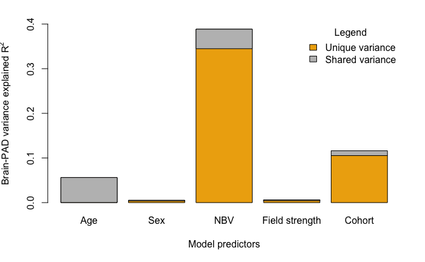

```r
bar.colors <- c("darkgoldenrod2", "grey")
barplot(t(as.matrix(h.p$IJ[,1:2])),
        names.arg = c("Age", "Sex", "NBV", "Field strength", "Cohort"),
        col = bar.colors,
         ylim = c(0,0.4),
        xlab = "Model predictors",
        ylab = expression(paste("Brain-PAD variance explained R"^"2")))
legend("topright", c("Unique variance", "Shared variance"), fill = bar.colors, bty = "n", title = "Legend")
```

```r
run_lm <- function(var, data) {
  m1 <- lmer(BrainPAD ~ data[[var]] +
               poly(age_at_scan, 2) +
               gender +
               field_strength +
               wb_vol_ratio_icv +
               (1|Cohort),
             data = data,
             control = lmerControl(optimizer = "Nelder_Mead"))
  return(m1)
}
```

## Main effect of group (MS vs. controls)

```r
fit <- run_lm("control0rest1", df.bl)
summary(fit)
```

```
Linear mixed model fit by REML. t-tests use Satterthwaite's method ['lmerModLmerTest']
Formula: BrainPAD ~ data[[var]] + poly(age_at_scan, 2) + gender + field_strength +      wb_vol_ratio_icv + (1 | Cohort)
   Data: data
Control: lmerControl(optimizer = "Nelder_Mead")

REML criterion at convergence: 9035

Scaled residuals:
   Min     1Q Median     3Q    Max
-5.138 -0.642 -0.033  0.619  4.726

Random effects:
 Groups   Name        Variance Std.Dev.
 Cohort   (Intercept)  8.64    2.94
 Residual             45.86    6.77
Number of obs: 1354, groups:  Cohort, 15

Fixed effects:
                      Estimate Std. Error       df t value Pr(>|t|)
(Intercept)            129.672      3.907 1183.794   33.19  < 2e-16 ***
data[[var]]MS            6.043      0.770 1265.898    7.85  8.8e-15 ***
poly(age_at_scan, 2)1 -166.368      8.526 1347.000  -19.51  < 2e-16 ***
poly(age_at_scan, 2)2  -15.356      6.924 1342.944   -2.22    0.027 *
gendermale              -0.936      0.396 1338.609   -2.37    0.018 *
field_strength3T        -1.855      0.735  408.407   -2.52    0.012 *
wb_vol_ratio_icv      -156.850      4.552 1346.999  -34.46  < 2e-16 ***
---
Signif. codes:  0 ‘***’ 0.001 ‘**’ 0.01 ‘*’ 0.05 ‘.’ 0.1 ‘ ’ 1

Correlation of Fixed Effects:
            (Intr) d[[]]M p(__,2)1 p(__,2)2 gndrml fld_3T
dat[[vr]]MS -0.366
ply(g__,2)1 -0.430 -0.040
ply(g__,2)2  0.049 -0.063  0.010
gendermale  -0.240  0.070  0.121    0.049
fld_strng3T -0.026  0.012 -0.009   -0.025   -0.051
wb_vl_rt_cv -0.961  0.212  0.466   -0.042    0.209 -0.051
```

## Estimated marginal means

Generate EMMs for all MS/CIS and healthy controls. Need to re-fit same model as above so that lme4 object can be read by emmeans.

```r
fit <- lmer(BrainPAD ~ control0rest1 +
               poly(age_at_scan, 2) +
               gender +
               field_strength +
              wb_vol_ratio_icv +
               (1|Cohort),
             data = df.bl,
             control = lmerControl(optimizer = "Nelder_Mead"))
emmeans(object = fit, pairwise ~ control0rest1)
```

```
$emmeans
 control0rest1 emmean   SE df lower.CL upper.CL
 control          4.2 1.04 37      2.1      6.4
 MS              10.3 0.83 16      8.5     12.1

Results are averaged over the levels of: gender, field_strength
Degrees-of-freedom method: kenward-roger
Confidence level used: 0.95

$contrasts
 contrast     estimate   SE   df t.ratio p.value
 control - MS       -6 0.77 1261 -7.800  <.0001

Results are averaged over the levels of: gender, field_strength
Degrees-of-freedom method: kenward-roger
```

# Meta-analysis looking at all the separate cohorts with MS/CIS patients and controls

### Check which cohorts contain healthy controls and patients.

```r
table(df.bl$subtype, df.bl$Cohort)
```

[output not shown]

### Create data.frame with summary data appropriate for meta-analysis.

```r
tmp0 <- df.bl %>% group_by(Cohort, control0rest1) %>% dplyr::summarise(length(control0rest1))
meta.cohorts <- as.list(tmp0[tmp0$control0rest1 == "control",1])$Cohort
tmp <- df.bl %>%
  filter(str_detect(Cohort, paste(meta.cohorts, collapse = "|")))
tmp1 <- tmp %>% group_by(Cohort, control0rest1) %>% dplyr::summarise(n = n(), Mean = mean(BrainPAD), SD  =  sd(BrainPAD))
tmp2 <- dcast(tmp1, Cohort ~ control0rest1, value.var = "n")
tmp3 <- dcast(tmp1, Cohort ~ control0rest1, value.var = "Mean")
tmp4 <- dcast(tmp1, Cohort ~ control0rest1, value.var = "SD")
names(tmp2) <- c("Cohort", "control_n", "MS_n")
names(tmp3) <- c("Cohort", "control_mean", "MS_mean")
names(tmp4) <- c("Cohort", "control_sd", "MS_sd")
tmp1x <- tmp %>% group_by(Cohort) %>% dplyr::summarise(pooled.SD  =  sd(BrainPAD))
meta.df <- join_all(list(tmp2,tmp3,tmp4, tmp1x), by = 'Cohort', type = 'left')
rm(list = ls(pattern = 'tmp*')) # remove temporary data frames
```

## Fit a random-effects meta-analysis using REML

Using the metafor package.

```r
meta.df <- escalc(m1i = control_mean, sd1i = pooled.SD, n1i = control_n, m2i = MS_mean, sd2i = pooled.SD, n2i = MS_n, measure = "MD", data = meta.df, digits = 2)
meta.results <- rma(yi, vi, data = meta.df, method = "REML")
print(meta.results)
```

```
Random-Effects Model (k = 6; tau^2 estimator: REML)

tau^2 (estimated amount of total heterogeneity): 11.8177 (SE = 13.0982)
tau (square root of estimated tau^2 value):      3.4377
I^2 (total heterogeneity / total variability):   59.03%
H^2 (total variability / sampling variability):  2.44

Test for Heterogeneity:
Q(df = 5) = 13.4832, p-val = 0.0192

Model Results:

estimate      se     zval    pval     ci.lb    ci.ub
 -9.4543  1.8649  -5.0695  <.0001  -13.1095  -5.7990  ***

---
Signif. codes:  0 ‘***’ 0.001 ‘**’ 0.01 ‘*’ 0.05 ‘.’ 0.1 ‘ ’ 1
```

```r
confint(meta.results)
```

```
       estimate  ci.lb   ci.ub
tau^2   11.8177 0.2530 84.1148
tau      3.4377 0.5030  9.1714
I^2(%)  59.0288 2.9923 91.1149
H^2      2.4407 1.0308 11.2548
```

## Forest plot of results

```r
plot.forest %<a-% {
forest(meta.results, ilab = cbind(meta.df$MS_n, meta.df$control_n), ilab.xpos = c(-30,-23), slab = meta.df$Cohort, digits = 1, xlab = "MS vs. Healthy control group mean difference", steps = 6, col = "red", cex = 1.25, pch = 22, bg = "blue"); text(c(-40, -30, -23), 7.6, c("Cohort", "MS n", "HC n"), font = 2, cex = 1.25)
}
plot.forest
cairo_pdf("plots/forest_plot.pdf", 6,5)
```

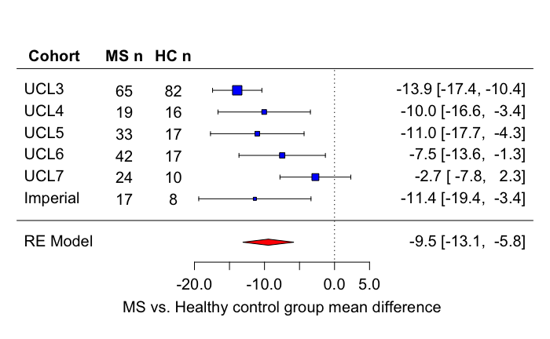

```r
plot.forest
dev.off()
```

## Linear regression analysis in cohort UCL3

```r
summary(lm(BrainPAD ~ control0rest1 + poly(age_at_baseline_scan1, 2) + gender + wb_vol_ratio_icv, data = subset(df.bl, df.bl$Cohort == "UCL3")))
```

```
Call:
lm(formula = BrainPAD ~ control0rest1 + poly(age_at_baseline_scan1,
    2) + gender + wb_vol_ratio_icv, data = subset(df.bl, df.bl$Cohort ==
    "UCL3"))

Residuals:
   Min     1Q Median     3Q    Max
-20.74  -3.82   0.12   4.08  14.32

Coefficients:
                                Estimate Std. Error t value Pr(>|t|)
(Intercept)                       98.758      9.912    9.96  < 2e-16 ***
control0rest1MS                    9.296      1.331    6.98  1.0e-10 ***
poly(age_at_baseline_scan1, 2)1  -46.263      7.574   -6.11  9.3e-09 ***
poly(age_at_baseline_scan1, 2)2    0.207      6.350    0.03     0.97
gendermale                        -0.740      1.103   -0.67     0.50
wb_vol_ratio_icv                -121.374     12.063  -10.06  < 2e-16 ***
---
Signif. codes:  0 ‘***’ 0.001 ‘**’ 0.01 ‘*’ 0.05 ‘.’ 0.1 ‘ ’ 1

Residual standard error: 6.3 on 141 degrees of freedom
Multiple R-squared:  0.672, Adjusted R-squared:  0.661
F-statistic: 57.9 on 5 and 141 DF,  p-value: <2e-16
```

# Brain-PAD by MS subtype

Using a linear mixed effect (LME) model, to compare subtypes. This analysis excluded controls. Adjusting for age, age^2, gender, field strength, normalised brain volume and cohort.

```r
subtypes <- run_lm("subtype", subset(df.bl, df.bl$subtype != "control"))
summary(subtypes)
```

```
Linear mixed model fit by REML. t-tests use Satterthwaite's method ['lmerModLmerTest']
Formula: BrainPAD ~ data[[var]] + poly(age_at_scan, 2) + gender + field_strength +      wb_vol_ratio_icv + (1 | Cohort)
   Data: data
Control: lmerControl(optimizer = "Nelder_Mead")

REML criterion at convergence: 7970

Scaled residuals:
   Min     1Q Median     3Q    Max
-4.860 -0.652 -0.013  0.607  4.523

Random effects:
 Groups   Name        Variance Std.Dev.
 Cohort   (Intercept)  5.35    2.31
 Residual             43.86    6.62
Number of obs: 1204, groups:  Cohort, 15

Fixed effects:
                      Estimate Std. Error       df t value Pr(>|t|)
(Intercept)            126.193      3.956 1133.060   31.90  < 2e-16 ***
data[[var]]RRMS          5.122      0.583  927.421    8.78  < 2e-16 ***
data[[var]]SPMS          6.585      0.938 1127.828    7.02  3.8e-12 ***
data[[var]]PPMS          4.507      1.069  370.482    4.21  3.2e-05 ***
poly(age_at_scan, 2)1 -172.683      8.698 1193.855  -19.85  < 2e-16 ***
poly(age_at_scan, 2)2  -16.532      6.884 1189.035   -2.40    0.016 *
gendermale              -0.764      0.415 1188.498   -1.84    0.066 .
field_strength3T        -0.626      0.713  230.278   -0.88    0.381
wb_vol_ratio_icv      -150.823      4.756 1194.873  -31.71  < 2e-16 ***
---
Signif. codes:  0 ‘***’ 0.001 ‘**’ 0.01 ‘*’ 0.05 ‘.’ 0.1 ‘ ’ 1

Correlation of Fixed Effects:
            (Intr) d[[]]R d[[]]S d[[]]P p(__,2)1 p(__,2)2 gndrml fld_3T
dt[[v]]RRMS -0.282
dt[[v]]SPMS -0.334  0.560
dt[[v]]PPMS -0.194  0.498  0.478
ply(g__,2)1 -0.365 -0.063 -0.182 -0.212
ply(g__,2)2  0.056  0.051 -0.108 -0.096  0.055
gendermale  -0.218  0.010 -0.007 -0.104  0.129    0.059
fld_strng3T -0.073  0.202  0.058  0.120 -0.021   -0.010   -0.053
wb_vl_rt_cv -0.974  0.162  0.258  0.098  0.398   -0.060    0.197 -0.016
```

```r
anova(subtypes)
```

```
Type III Analysis of Variance Table with Satterthwaite's method
                     Sum Sq Mean Sq NumDF DenDF F value Pr(>F)
data[[var]]            3701    1234     3   773   28.13 <2e-16 ***
poly(age_at_scan, 2)  17365    8683     2  1191  197.95 <2e-16 ***
gender                  149     149     1  1188    3.39  0.066 .
field_strength           34      34     1   230    0.77  0.381
wb_vol_ratio_icv      44108   44108     1  1195 1005.61 <2e-16 ***
---
Signif. codes:  0 ‘***’ 0.001 ‘**’ 0.01 ‘*’ 0.05 ‘.’ 0.1 ‘ ’ 1
```

## Brain-PAD estimated marginal means for subtypes

Generate EMMs for all MS subtypes.

```r
fit_subtype <- lmer(BrainPAD ~ subtype +
               poly(age_at_scan, 2) +
               gender +
               field_strength +
              wb_vol_ratio_icv +
               (1|Cohort),
            # data = subset(df.bl, df.bl$control0rest1 != "control"),
            data = df.bl,
             control = lmerControl(optimizer = "Nelder_Mead"))
emmeans(object = fit_subtype, pairwise ~ subtype)
```

```
$emmeans
 subtype emmean   SE df lower.CL upper.CL
 control    4.3 0.90 50      2.5      6.1
 CIS        6.4 0.80 33      4.8      8.1
 RRMS      11.6 0.69 20     10.1     13.0
 SPMS      13.0 0.95 72     11.1     14.9
 PPMS      10.4 0.97 64      8.5     12.4

Results are averaged over the levels of: gender, field_strength
Degrees-of-freedom method: kenward-roger
Confidence level used: 0.95

$contrasts
 contrast       estimate   SE   df t.ratio p.value
 control - CIS      -2.2 0.92  724 -2.400  0.1300
 control - RRMS     -7.3 0.81  868 -9.000  <.0001
 control - SPMS     -8.7 1.01 1227 -8.600  <.0001
 control - PPMS     -6.2 0.95 1296 -6.500  <.0001
 CIS - RRMS         -5.1 0.58 1100 -8.900  <.0001
 CIS - SPMS         -6.6 0.92 1295 -7.200  <.0001
 CIS - PPMS         -4.0 1.01  659 -4.000  <.0001
 RRMS - SPMS        -1.4 0.76 1342 -1.900  0.3200
 RRMS - PPMS         1.1 0.87  700  1.300  0.6900
 SPMS - PPMS         2.6 0.99 1110  2.600  0.0700

Results are averaged over the levels of: gender, field_strength
Degrees-of-freedom method: kenward-roger
P value adjustment: tukey method for comparing a family of 5 estimates
```

Save table for importing into Word

```r
x <- as.data.frame(emmeans(object = fit, pairwise ~ subtype)$contrasts)
write.table(format(x, digits = 3), file = "~/Desktop/tmp.txt", sep = ",", quote = F, row.names = F)
```

Plot the EMMs and confidence intervals

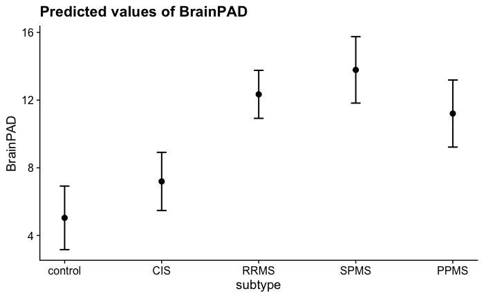

## Brain-PAD boxplot by MS subtype

```r
# calculate Ns
control_n <- with(df.bl, table(subtype))["control"]
cis_n <- with(df.bl, table(subtype))["CIS"]
rrms_n <- with(df.bl, table(subtype))["RRMS"]
spms_n <- with(df.bl, table(subtype))["SPMS"]
ppms_n <- with(df.bl, table(subtype))["PPMS"]
plot.pryr %<a-% {
with(df.bl, ehplot(BrainPAD, groups = subtype, ylim = c(-20,52), pch = 21, bg = ms.palette[as.numeric(subtype)], box = T, offset = 0.1, intervals = 50, xlab = "Groups", ylab = "Brain-PAD (years)", main = "Baseline Brain-PAD by study group")) +
  abline(0,0, lty = 2) +
  text(1,51, paste("N = ", control_n, sep = ""), cex = 0.8) +
  text(2,51, paste("N = ", cis_n, sep = ""), cex = 0.8) +
  text(3,51, paste("N = ", rrms_n, sep = ""), cex = 0.8) +
  text(4,51, paste("N = ", spms_n, sep = ""), cex = 0.8) +
  text(5,51, paste("N = ", ppms_n, sep = ""), cex = 0.8)
}
plot.pryr
```

```
integer(0)
```

```r
cairo_pdf("plots/MS_UCL_MAGNIMS_combined_group_Brain-PAD.pdf", 8,8)
```

```r
plot.pryr
```

```
integer(0)
```

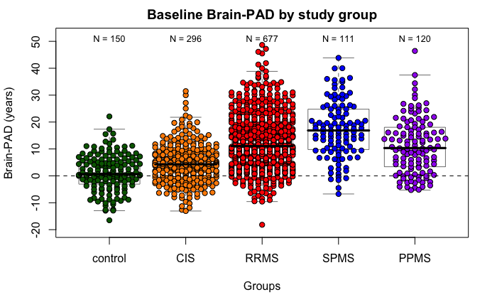

```r
dev.off()
```

## Brain-PAD boxplot by cohort and by MS subtype

### Also, Estimate marginal means plot

Uses sjPlot to calculated EMMs from linear regression model

```
Not enough tags labels in list. Using letters instead.
```

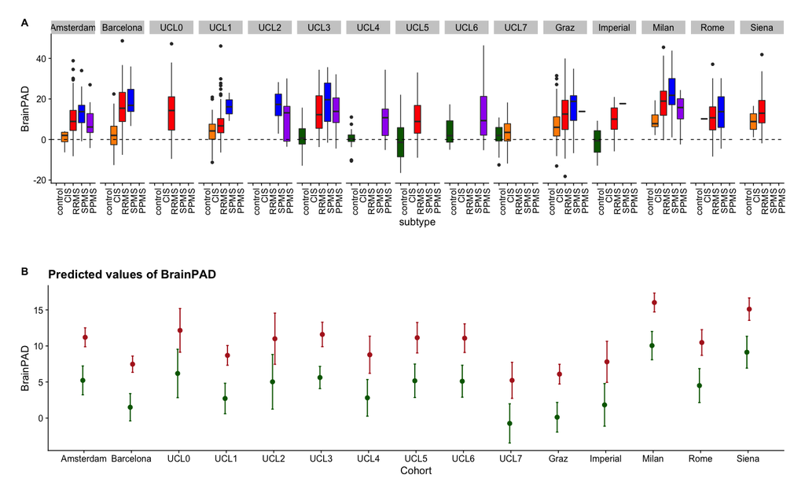

```r
p1 <- ggplot(df.bl, aes(x = subtype, y = BrainPAD, fill = subtype)) +
  geom_boxplot() +
  facet_wrap(df.bl$Cohort, nrow = 1) +
  geom_hline(aes(yintercept = 0), lty = 2) +
  theme_cowplot() +
  theme(axis.text.x = element_text(angle = 90, hjust = 1)) +
  theme(legend.position = "none") +
  scale_fill_manual(values = ms.palette)
fit <- lm(BrainPAD ~ control0rest1 + poly(age_at_baseline_scan1, 2) + gender + field_strength + wb_vol_ratio_icv + Cohort, data = df.bl)
p2 <- plot_model(fit, type = "emm", terms = c("Cohort", "control0rest1"), colors = c("darkgreen", "firebrick"), show.legend = F) + theme_cowplot()
plot_grid(list(p1,p2))
```

```r
ggsave("~/Work/Brain ageing/Collaborations/MS/plots/brainPAD_cohort_subtype_boxplot_EMM_plot.pdf", width = 15, height = 10, useDingbats = FALSE)
```